# Analysis of the Beverage Production Factors that Impact Product pH at ABC Beverage Company - Technical Report

## `Mnf.Flow` Analysis

According to the random forest and linear regression (with scaled data) models, the variable which accounts for the highest proportion of model variance is the `Mnf.Flow` (minimum night flow?) measure.

However as we investigate further into the predictive value of this variable, we note its tri-modal shape, with a huge spike at -100, accounting for over 46% of all values. There is another spike close to 0 (3% of observations), and then a third near-normal distribution centered around 140. Furthermore, when we test the correlation between `PH` and `Mnf.Flow` for only strictly positive values of `Mnf.Flow`, any correlation almost completely disappears (-0.05567).

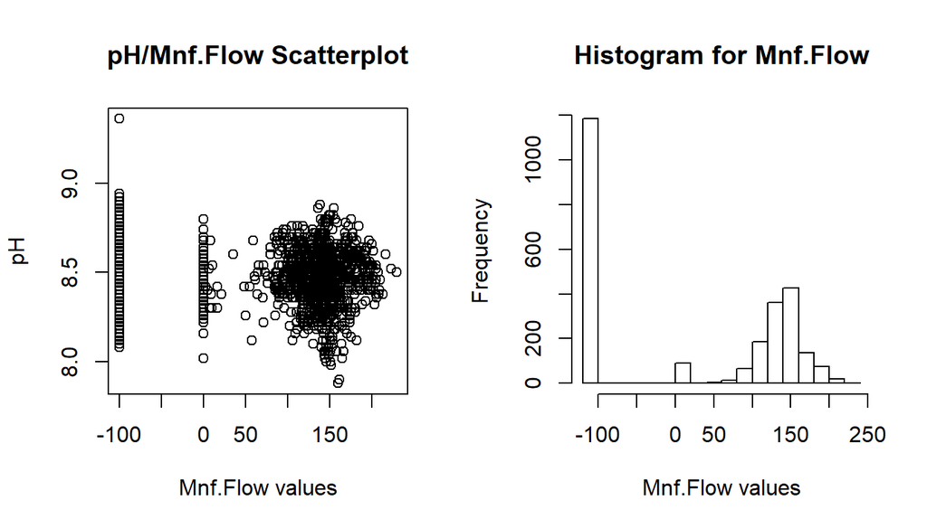

The irregular distribution of the data for this variable allows us to consider that we are actually looking at four distinct manufacturing processes, and that the -100 value is actually more of a categorical placekeeper. As such, we delve into this variable further by mutating into four ordinal values separated by buckets of `Mnf.FLow` in the following ranges {1: [-1000, -1), 2: [-1, 1), 3: [1, 140), 4: [140, 1000]}

Here we are careful to retain the original dataset, rather than one which removed incomplete cases. We do so because a disproportionate amount of cases of type 2 (in range of -1 to 1) have at least one missing value. In fact only 1% of the observations in that range are complete.

```
##
##    1    2    3    4
## 1184   79  637  669
```

With further evidence from the means of the binned Mnf.Flow data, we observe that although type 1 (negative Mnf.Flow) have much higher pH on average, type 2 (near-zero) has much lower pH, types 3 and 4 (positive above and below mean values) have little difference in mean pH. This is supported by the lack of correlation with pH with Mnf.Flow reported above, and the violinplot of pH values for each type below:

```
## [1] "mean of type 1 (neg.) is:  8.633"
```

```
## [1] "mean of type 2 (near-zero) is:  8.4456"
```

```
## [1] "mean of type 3 (pos. below mean) is:  8.4786"
```

```
## [1] "mean of type 4 is (pos. above mean):  8.4667"
```

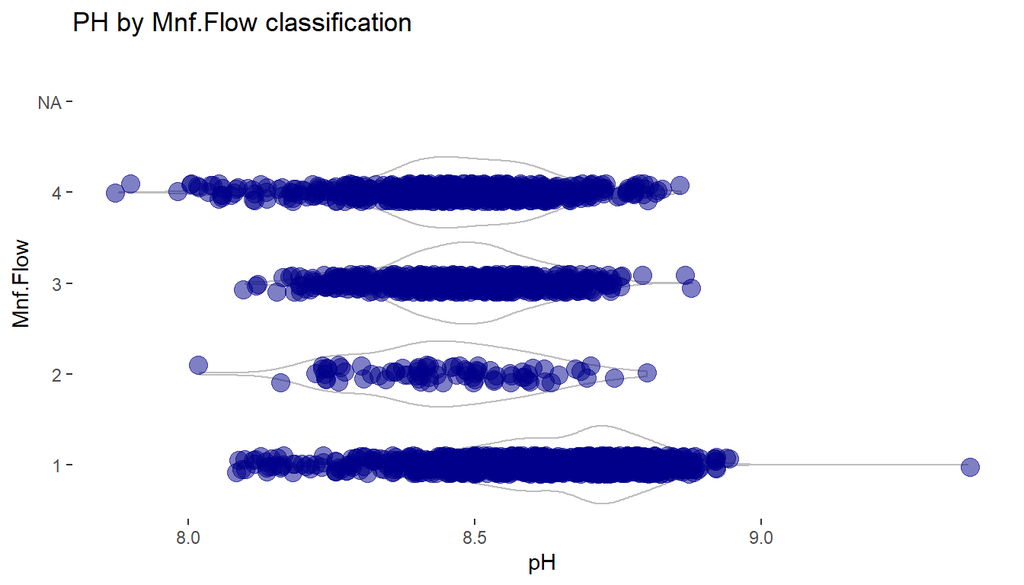

As such, the greatest predictor of beverage pH is whether Mnf.Flow has a negative value. The quantity itself is not likely to be useful as a model input as the negative value likely references an entirely different production process.

## Modeling by Brand

In another experiment we divided the dataset into subsets according to `Brand.Code` in order to assess what production processes are most relevant for each brand type. We imputed missing values by replacing them with the trimmed mean and then applied a random forest model to each of the four sets. Our aim was to determine if the variables found to be most important for the whole dataset carry through to the subsets.

The mean pH for our dataset is 8.55, however, it is possible that pH may vary with brand profile. From this violin plot, we observe that the distribution of pH values for Brand D tends to be above mean, while that of Brand C is markedly below mean. We further investigated what factors determine the acidic signature of Brand C, with the conclusion that lower balling method levels (which promote solution alkalinity) may at least partially contribute.

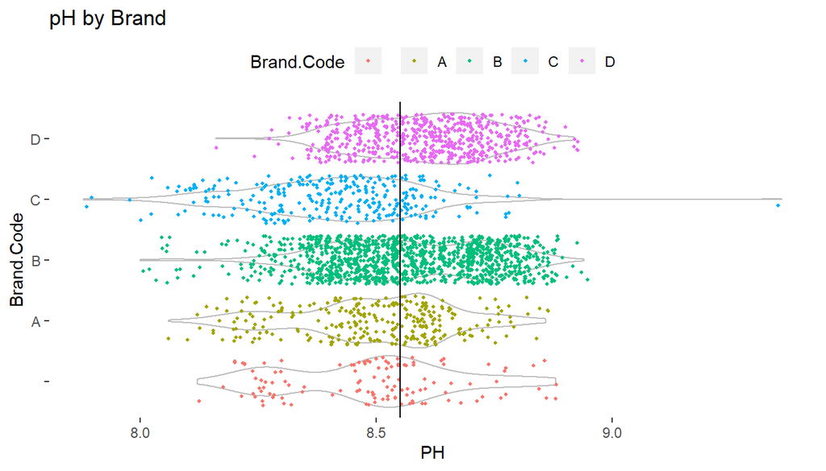

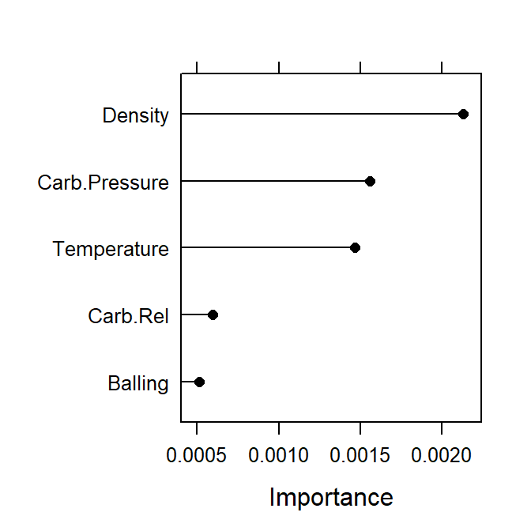

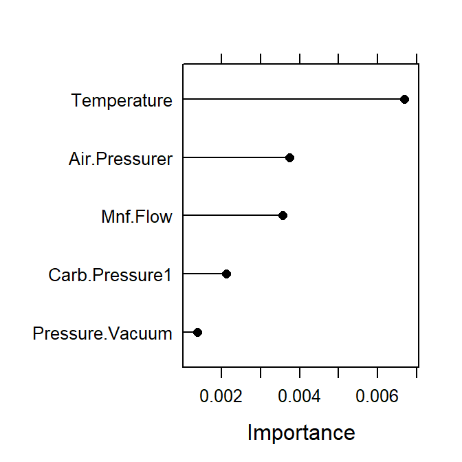

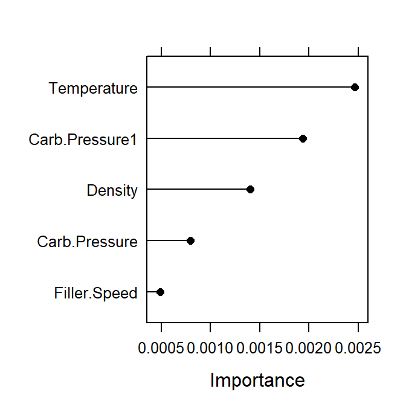

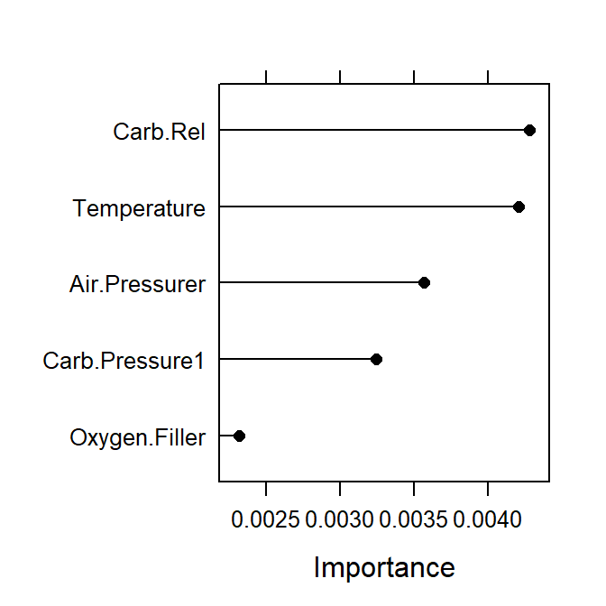